# Red Wine Quality Analysis by David Blum

# Multivariate Analysis

Wines of high quality tend to follow a few rules:

1. Percent Alcohol above 11%
2. Volatile Acidity (acetic acid) below .5 g/dm^3
3. Citric Adid above .25 g/dm^3
4. Sulphates are between .5 g/dm^3 and 1.0 g/dm^3

It’s not a guarantee for wines that meet these specifications will be of high quality, however it appears to be a good indicator. The range for high quality sulphates does not appear to be a strong enough factor for quality.

# Final Plots

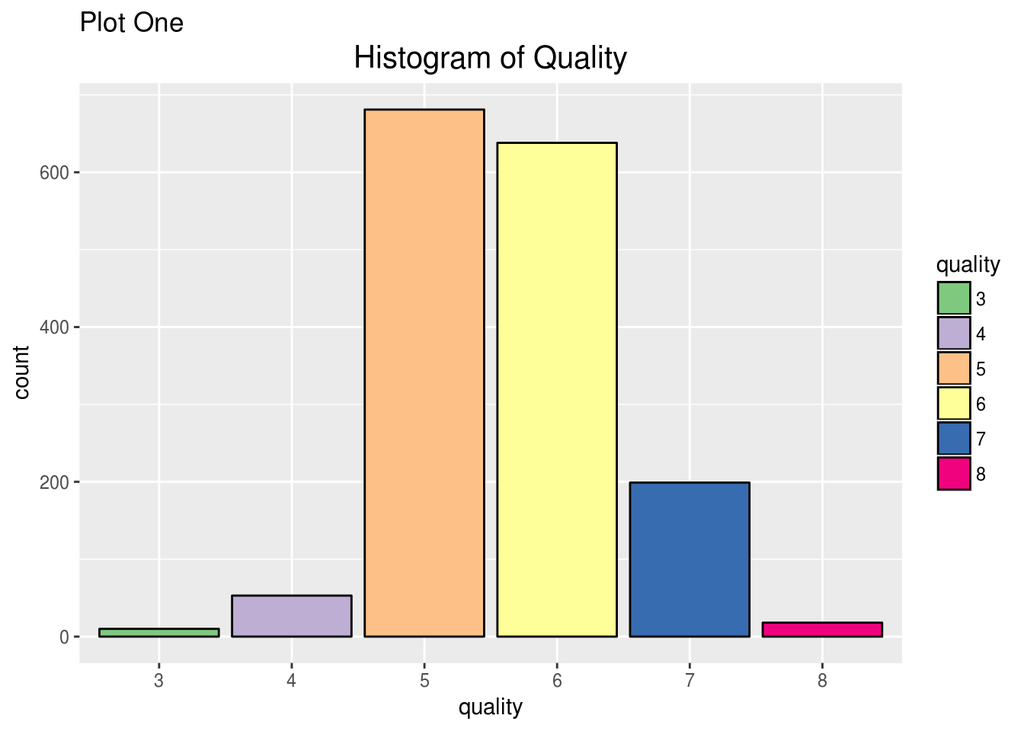

#### Description of Plot 1

Quality is rated on a scale of 0-10, however the only scores that were assigned were from 3-8. Most wines are mid quality with few low and high quality wines. Any clustering of quality=7 and quality=8 wines is important in analysis.

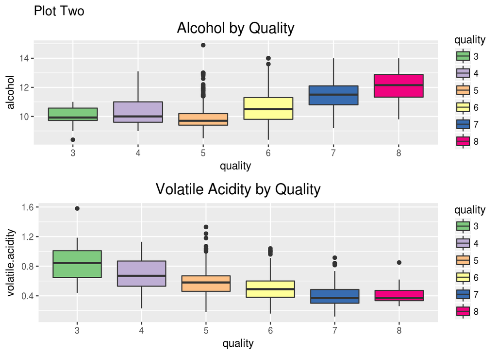

#### Description of Plot 2

The two most corellated variables (alcohol and volatile.acidity) were compared to quality. Quality has a positive correlation with alcohol and a negative correaltion with volatile acidity.

Most high quality wines exceed 11% alcohol by volume and have below .5 g/dm^3 of volatile acids (acetic acid).

[figure not shown]

#### Description of Plot 3

Many of the higher tier alcohols (quality=7 and quality=8) have citric acid citric acid values above .25 and a range of sulphates [.5, 1.0].

# Reflection

Of the 1599 red wines observed only a few variables have a moderate to slightly moderate impact on the quality of a wine. The most impactful variables with their correlation values are:

- alcohol : 0.48
- volatile.acidity: -0.39
- sulphates: .25
- citric.acid: .23

Variables with positive corellation values generally affect wine positively, whereas the opposite is true with negative values.

Alcohol is a much stronger indicator for quality than any other variable. Being a common variable listed on the label of a wine I wonder if the knowledge of alcohol percentage created bias during the process of wine quality ratings.

Generally wines that are highly rated typically follow 4 main attributes (ranked highest first):

1. Percent Alcohol above 11%
2. Volatile Acidity (acetic acid) below .5 g/dm^3
3. Sulphates are between .5 g/dm^3 and 1.0 g/dm^3
4. Citric Adid above .25 g/dm^3

There are exceptions for high quality wines that do not adhere to these guidelines, but most good wines have at least a few of these qualities.

To investigate this data further I would also like to know the age and average price of the wine. Age is typically a factor used to sell wine at a more expensive price, and a more expensive item can be associated with higher quality.

# References

P. Cortez, A. Cerdeira, F. Almeida, T. Matos and J. Reis. Modeling wine preferences by data mining from physicochemical properties. In Decision Support Systems, Elsevier, 47(4):547-553. ISSN: 0167-9236.

Available at: [@Elsevier] http://dx.doi.org/10.1016/j.dss.2009.05.016 [Pre-press (pdf)] http://www3.dsi.uminho.pt/pcortez/winequality09.pdf [bib] http://www3.dsi.uminho.pt/pcortez/dss09.bib